# Data Challenge 1

Yifan Lu

## Github Repository Link:

https://github.com/cclyfblink/Data_Challenge_1_Yifan_Lu

## load in the required libraries

```r
library(readr)
library(tidyverse)
library(here)
## read in the data using here() function
state_milk_production <- read_csv(here("data/state_milk_production.csv"))
clean_cheese <- read_csv(here("data/clean_cheese.csv"))
fluid_milk_sales <- read_csv(here("data/fluid_milk_sales.csv"))
milk_products_facts <- read_csv(here("data/milk_products_facts.csv"))
milkcow_facts <- read_csv(here("data/milkcow_facts.csv"))
## disable scientific notation
options(scipen = 999)
```

# Figure 1

Make a scatter plot showing the milk production in pounds versus the average number of milk cows using milkcow_facts. Write a caption for this plot.

The x-axis will be the number of milk cows (in millions) and the y-axis will be milk production (in millions of pounds) Color the plot using a continuous variable of years Label the axes (do not use the variable name) Add a title for the plot Label the legend (do not use the variable name)

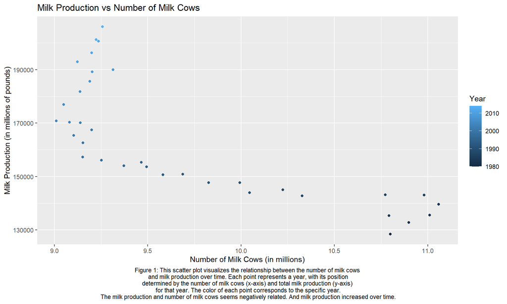

```r
# Convert milk production from pounds to millions of pounds
milkcow_facts$milk_production_lbs_millions <- milkcow_facts$milk_production_lbs / 1e6
# Convert the number of milk cows to millions
milkcow_facts$avg_milk_cow_number_millions <- milkcow_facts$avg_milk_cow_number / 1e6

# Plotting the data
milkcow_facts %>%
    ggplot(aes(
        x = avg_milk_cow_number_millions, # Set x-axis to the number of milk cows (in millions)
        y = milk_production_lbs_millions, # Set y-axis to milk production (in millions of pounds)
        color = year # Color the plot using a continuous variable of years
    )) +
    geom_point() + # Plot the data points in the graph
    scale_color_continuous(name = "Year") + # Color the year continuously
    labs(
        title = "Milk Production vs Number of Milk Cows", # Set the title of the plot
        x = "Number of Milk Cows (in millions)", # Label for x-axis
        y = "Milk Production (in millions of pounds)", # Label for y-axis
        caption = "Figure 1: This scatter plot visualizes the relationship between the number of milk cows\n and milk production over time. Each point represents a year, with its position\n determined by the number of milk cows (x-axis) and total milk production (y-axis) \n for that year. The color of each point corresponds to the specific year.\n The milk production and number of milk cows seems negatively related. And milk production increased over time." # Caption for the plot
        ) +
    theme(plot.caption = element_text(hjust = 0.5)) # Adjust the caption to middle
```

# Figure 2

Examine the milk total milk production in each region over time using state_milk_production. We will plot line plots for the milk production versus the year faceted by region. Write a caption for this plot.

First, find the total production of milk each year by region (hint: use summarise() to find this) The x-axis will be time and the y-axis will be total milk produced (in millions of pounds) in the region that year Make line plots and color each line a different color Facet the plot by region Label the axes (do not use the variable name) Add a title for the plot Remove the legend from the plot

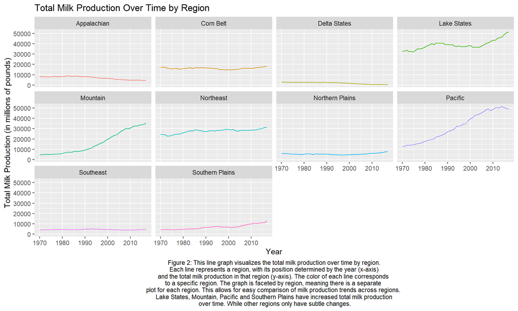

```r
# Group the data by year and region
state_milk_production %>%
    group_by(year, region) %>%
    # Summarise the total milk production by region in millions of pounds
    summarise(total_production_by_region_millions = sum(milk_produced)/ 1e6) %>%
    # Plot the data
    ggplot(aes(
        x = year, # Set x-axis to year
        y = total_production_by_region_millions, # Set y-axis to total milk production by region in millions of pounds
        color = region # Color the plot by region
    )) +
    geom_line() + # Plot the data as a line graph
    facet_wrap(~region) + # Create a separate plot for each region
    labs(
        x = "Year", # Label for x-axis
        y = "Total Milk Production (in millions of pounds)", # Label for y-axis
        title = "Total Milk Production Over Time by Region", # Set the title of the plot
        caption = "Figure 2: This line graph visualizes the total milk production over time by region.\n Each line represents a region, with its position determined by the year (x-axis) \nand the total milk production in that region (y-axis). The color of each line corresponds \nto a specific region. The graph is faceted by region, meaning there is a separate \nplot for each region. This allows for easy comparison of milk production trends across regions. \n Lake States, Mountain, Pacific and Southern Plains have increased total milk production \n over time. While other regions only have subtle changes." # Caption for the plot
    ) +
    theme(
        legend.position = "none", # Hide the legend
        plot.caption = element_text(hjust = 0.5) # Adjust the caption to middle
    )
```